# 독고다이_YES24_20251210.html

202016222 류태영

2025-12-15

# 크롤링 및 정제

```r
# -----------------------------------------------------
# 🧩 Selenium 초기 연결
# -----------------------------------------------------
# Selenium 초기 연결
remDr = rsDriver(remoteServerAddr = "localhost",
                 browser = "chrome",
                 geckover = NULL,
                 iedrver = NULL,
                 chromever = NULL,
                 phantomver = NULL,
                 port = 8300L)
remDr_client <- remDr$client
remDr_client$open()


# -----------------------------------------------------
# 🧩 안정화 유틸 함수들
# -----------------------------------------------------

# 펼쳐보기 버튼 클릭
click_expand_if_exists <- function() {
  tryCatch({
    button <- remDr_client$findElement("css selector", "em.txt.txt_open")
    button$clickElement(); Sys.sleep(1)
  }, error = function(e) NULL)
}

# 중복 제거
dedup_text <- function(text) {
  lines <- str_split(text, "\n|<br>|<br/>|<br />", simplify = TRUE)
  lines <- str_trim(lines)
  lines <- lines[lines != ""]
  paste(unique(lines), collapse = " ")
}

# 필드 정제
sanitize_field <- function(text) {
  if (is.na(text)) return(NA_character_)
  text %>%
    str_replace_all("<br>|<br/>|<br />", " ") %>%
    str_replace_all("[\r\n]+", " ") %>%
    str_replace_all("\"", "'") %>%
    str_trim()
}

# 안전 추출
safe_extract <- function(html, selector) {
  tryCatch({
    node <- html %>% html_node(selector)
    if (is.na(node) || length(node) == 0) return(NA_character_)
    html_text(node, trim = TRUE)
  }, error = function(e) NA_character_)
}

# 저자 여러 개인 경우
extract_authors <- function(book_page) {
  tryCatch({
    authors <- book_page %>% html_nodes("span.gd_auth a") %>% html_text(trim = TRUE)
    if (length(authors) == 0) return(NA_character_)
    paste(authors, collapse = ", ")
  }, error = function(e) NA_character_)
}

# 별점 이상치 제거
clean_rating <- function(raw) {
  tryCatch({
    clean <- gsub(",", "", raw)
    num <- as.numeric(clean)
    if (!is.na(num) && num > 10) NA_character_ else as.character(num)
  }, error = function(e) NA_character_)
}

# 안정적 로딩 감지
wait_until_loaded_safe <- function(selector, timeout = 20) {
  for (i in 1:timeout) {
    try({
      nodes <- remDr_client$findElements("css selector", selector)
      if (length(nodes) > 0) return(TRUE)
    }, silent = TRUE)
    Sys.sleep(1)
  }
  return(FALSE)
}


# -----------------------------------------------------
# 🧩 대학교재 중분류 목록
# -----------------------------------------------------
middle_categories <- tribble(
  ~name,           ~url,
  "경상계열",       "https://www.yes24.com/product/category/display/001001014008",
  "공학계열",       "https://www.yes24.com/product/category/display/001001014019",
  "농축산학계열",   "https://www.yes24.com/product/category/display/001001014007",
  "법학계열",       "https://www.yes24.com/product/category/display/001001014011",
  "사범대계열",     "https://www.yes24.com/product/category/display/001001014006",
  "사회과학계열",   "https://www.yes24.com/product/category/display/001001014010",
  "어문학계열",     "https://www.yes24.com/product/category/display/001001014002",
  "예체능/문학/기타계열","https://www.yes24.com/product/category/display/001001014009",
  "의약학/간호계열", "https://www.yes24.com/product/category/display/001001014005",
  "인문학계열",     "https://www.yes24.com/product/category/display/001001014001",
  "자연과학계열",   "https://www.yes24.com/product/category/display/001001014003"
)

# -----------------------------------------------------
# 📂 디렉터리 생성
# -----------------------------------------------------
dir.create("book_html_univ", showWarnings = FALSE)
dir.create("book_csv_univ_retry", showWarnings = FALSE)
done_categories <- if (file.exists("done_univ_categories.txt"))
  readLines("done_univ_categories.txt") else character(0)

univ_all_books <- list()


# =====================================================
# 📚📚📚  대학교재 전체 크롤링 시작
# =====================================================
for (i in seq_len(nrow(middle_categories))) {

  category_name <- middle_categories$name[i]
  category_url  <- middle_categories$url[i]
  safe_name     <- str_replace_all(category_name, "[^[:alnum:]가-힣]", "_")
  all_books_total <- list()

  if (category_name %in% done_categories) {
    cat(glue("⏭️ {category_name} 이미 완료됨 - 건너뜀\n"))
    next
  }

  cat(glue("\n\n==============================\n📖 {category_name} — 시작\n==============================\n"))

  # 페이지 오픈
  remDr_client$navigate(category_url)
  wait_until_loaded_safe(".itemUnit")

  # 정렬 최신순
  tryCatch({
    remDr_client$findElement("css selector", "a.sort_gb[data-search-value='RECENT']")$clickElement()
    Sys.sleep(1.2)
  }, error = function(e) NULL)

  # 페이지 120개 보기
  tryCatch({
    sel <- remDr_client$findElement("css selector", "select#pg_size")
    remDr_client$executeScript("arguments[0].value = '120'; arguments[0].dispatchEvent(new Event('change'));", list(sel))
    Sys.sleep(2)
  }, error = function(e) NULL)


  # -----------------------------------------------------
  # 1) 📌 전체 책 링크 수집
  # -----------------------------------------------------
  links_file <- glue("book_links_univ_{safe_name}.txt")

  if (file.exists(links_file)) {
    book_links <- readLines(links_file)
  } else {
    book_links <- c()
    repeat {
      page_html <- read_html(remDr_client$getPageSource()[[1]])

      new_links <- page_html %>%
        html_nodes(".itemUnit .info_name .gd_name") %>%
        html_attr("href") %>%
        paste0("https://www.yes24.com", .) %>%
        .[str_detect(., "/product/goods/\\d+")]

      book_links <- unique(c(book_links, new_links))

      current_page_node <- remDr_client$findElement("css selector", "div.yesUI_pagen strong.num")
      current_page      <- as.numeric(current_page_node$getElementText()[[1]])
      next_page_links   <- remDr_client$findElements("css selector", "div.yesUI_pagen a.num")

      next_found <- FALSE
      for (link in next_page_links) {
        page_num <- as.numeric(link$getElementAttribute("title")[[1]])
        if (!is.na(page_num) && page_num == current_page + 1) {
          link$clickElement(); Sys.sleep(2)
          next_found <- TRUE
          break
        }
      }
```

```r
      if (!next_found) {
        next_block <- tryCatch({
          remDr_client$findElement("css selector", "div.yesUI_pagen a.next")
        }, error = function(e) NULL)
        if (!is.null(next_block)) {
          next_block$clickElement(); Sys.sleep(2)
        } else break
      }
    }
    writeLines(book_links, links_file)
  }


  # -----------------------------------------------------
  # 2) 📌 개별 책 크롤링 (안정화 적용)
  # -----------------------------------------------------

  existing_files <- list.files("book_csv_univ_retry",
                               pattern = glue("^{safe_name}_\\d+\\.csv$"))

  existing_ids <- str_extract(existing_files, "\\d+")

  for (j in seq_along(book_links)) {

    book_url <- book_links[j]
    book_id  <- str_extract(book_url, "(?<=/goods/)\\d+")

    if (book_id %in% existing_ids) next

    cat(glue("📚 {category_name} {j}/{length(book_links)}: {book_url}\n"))

    html_path <- glue("book_html_univ/{safe_name}_{book_id}.html")


    # ----------------------------
    # 🔥 navigate 실패 시 Skip
    # ----------------------------
    if (!file.exists(html_path)) {

      nav_ok <- tryCatch({
        remDr_client$navigate(book_url)
        TRUE
      }, error = function(e) FALSE)

      if (!nav_ok) {
        cat(glue("❌ navigate 실패 → Skip\n"))
        next
      }

      loaded_ok <- wait_until_loaded_safe(".gd_name", timeout = 20)
      if (!loaded_ok) {
        cat(glue("❌ 로딩 Timeout → Skip\n"))
        next
      }

      click_expand_if_exists()

      book_html <- tryCatch({
        remDr_client$getPageSource()[[1]]
      }, error = function(e) NULL)

      if (is.null(book_html)) {
        cat("❌ PageSource 실패 → Skip\n")
        next
      }

      write_file(book_html, html_path)
    }


    # ----------------------------
    # 🔥 HTML 파싱 실패 시 Skip
    # ----------------------------
    book_page <- tryCatch({
      read_html(html_path, options = "HUGE")
    }, error = function(e) NULL)

    if (is.null(book_page)) {
      cat("❌ HTML 파싱 실패 → Skip\n")
      next
    }


    # ----------------------------
    # 🔥 정상 데이터 추출
    # ----------------------------
    page_text   <- book_page %>% html_text()

    pub_review  <- str_extract(page_text,
                               regex("출판사 리뷰.*?회원리뷰", dotall = TRUE)) %>%
      str_remove("출판사 리뷰") %>% str_remove("회원리뷰") %>%
      sanitize_field()

    book_df <- tibble(
      대분류     = "대학교재",
      중분류     = category_name,
      책ID       = book_id,
      제목       = sanitize_field(safe_extract(book_page, ".gd_name")),
      저자전체   = sanitize_field(extract_authors(book_page)),
      출판사     = sanitize_field(safe_extract(book_page, ".gd_pub a")),
      발행일     = sanitize_field(safe_extract(book_page, ".gd_date")),
      별점       = clean_rating(safe_extract(book_page, "em.yes_b")),
      판매지수   = sanitize_field(safe_extract(book_page, "span.gd_sellNum")),
      가격       = sanitize_field(safe_extract(book_page, "em.yes_m")),
      품목정보   = sanitize_field(safe_extract(book_page, "#infoset_specific .infoSetCont_wrap")),
      관련분류   = sanitize_field(safe_extract(book_page, "#infoset_goodsCate .infoSetCont_wrap")),
      책소개     = sanitize_field(safe_extract(book_page, "#infoset_introduce .infoWrap_txtInner")),
      목차       = sanitize_field(safe_extract(book_page, "#infoset_toc .infoSetCont_wrap")),
      저자소개   = sanitize_field(safe_extract(book_page, "#contents_author_grp1 .author_info.info_origin")),
      역자       = sanitize_field(safe_extract(book_page, "#contents_author_grp2 .author_info.info_origin")),
      만든이코멘트 = sanitize_field(safe_extract(book_page, "#infoset_authorCmt .infoSetCont_wrap")),
      출판사리뷰 = pub_review
    )

    write_csv(book_df, file = glue("book_csv_univ_retry/{safe_name}_{book_id}.csv"),
              na = "", quote = "all")

    all_books_total[[length(all_books_total) + 1]] <- book_df
  }

  # -----------------------------------------------------
  # 3) 📌 한 중분류 CSV 저장
  # -----------------------------------------------------
  all_books_df <- bind_rows(all_books_total)
  write_csv(all_books_df, file = glue("yes24_books_univ_{safe_name}.csv"), na = "")

  univ_all_books[[length(univ_all_books) + 1]] <- all_books_df

  write(category_name, file = "done_univ_categories.txt", append = TRUE)

  cat(glue("📁 중분류 CSV 저장 완료: yes24_books_univ_{safe_name}.csv\n"))
}

# =====================================================
# 📦 전체 통합 저장
# =====================================================
if (length(univ_all_books) > 0) {
  all_df <- bind_rows(univ_all_books)
  write_csv(all_df, "yes24_books_univ_all.csv", na = "")
  message("✅ 전체 저장 완료: yes24_books_univ_all.csv")
} else {
  message("⚠️ 저장된 책이 없습니다.")
}


# -------------------------------------------------------
# 📂 1. book_csv_univ_retry 폴더 파일 목록 읽기
# -------------------------------------------------------
files <- list.files("book_csv_univ_retry", full.names = TRUE)

total_files <- length(files)
cat(glue("📌 전체 책 CSV 파일 수: {total_files}\n\n"))

# 카테고리별 저장 리스트
category_dfs <- list()

# -------------------------------------------------------
# 📘 2. 파일 하나씩 읽으면서 진행상황 출력
# -------------------------------------------------------
for (idx in seq_along(files)) {

  f <- files[idx]
  pct <- round(idx / total_files * 100, 2)

  cat(glue("▶ [{idx}/{total_files}] ({pct}%) 처리 중: {basename(f)}\n"))

  # 파일 읽기 + 전체 문자형 변환
  df <- tryCatch({
    read_csv(f, show_col_types = FALSE) %>%
      mutate(across(everything(), as.character))
  }, error = function(e) {
    cat(glue("❌ ERROR 읽기 실패: {basename(f)}\n"))
    return(NULL)
  })

  if (is.null(df)) next

  cat_name <- df$중분류[1]

  if (is.na(cat_name)) {
    cat(glue("⚠️ 중분류 NA → 스킵: {basename(f)}\n"))
    next
  }

  # 누적 저장
  if (!cat_name %in% names(category_dfs)) {
    category_dfs[[cat_name]] <- df
  } else {
    category_dfs[[cat_name]] <- bind_rows(category_dfs[[cat_name]], df)
  }

  current_count <- nrow(category_dfs[[cat_name]])
  cat(glue("   ↳ 중분류 '{cat_name}' 누적: {current_count} 권\n\n"))
}


cat("\n=============================\n📘 중분류별 CSV 저장 시작\n=============================\n\n")
```

```r
# -------------------------------------------------------
# 📚 3. 중분류 CSV 저장
# -------------------------------------------------------
for (cat_name in names(category_dfs)) {

  safe_name <- str_replace_all(cat_name, "[^[:alnum:]가-힣]", "_")
  rows <- nrow(category_dfs[[cat_name]])

  write_csv(
    category_dfs[[cat_name]],
    glue("yes24_books_univ_{safe_name}.csv"),
    na = ""
  )

  cat(glue("✔ 저장 완료: yes24_books_univ_{safe_name}.csv  (행: {rows})\n"))
}

cat("\n=============================\n📦 전체 통합 CSV 생성 시작\n=============================\n\n")

# -------------------------------------------------------
# 📦 4. 전체 통합 CSV 저장
# -------------------------------------------------------
all_df <- bind_rows(category_dfs)
write_csv(all_df, "yes24_books_univ_all.csv", na = "")

df <- read_csv("yes24_books_univ_all.csv", show_col_types = FALSE)

# 🔥 1) 기본 로드
# -------------------------------
df_clean <- df

# -------------------------------
# 🔥 2) 책ID/가격/판매지수/별점 타입 통일
# -------------------------------
df_clean <- df_clean %>%
  mutate(
    책ID = as.character(책ID),                  # 지수로 저장된 ID 복원
    가격 = parse_number(가격),                 # "29,000원" → 29000
    판매지수 = parse_number(판매지수),         # "100" "1,200" 등 숫자 변환
    별점 = as.numeric(별점)                    # 10, 8.5 등 숫자형
  )

# -------------------------------
# 🔥 3) 발행일 정규화
#   예: "2021년 03월 15일" → "2021-03-15"
# -------------------------------
df_clean <- df_clean %>%
  mutate(
    발행일 = 발행일 %>%
      str_replace_all("년", "-") %>%
      str_replace_all("월", "-") %>%
      str_replace_all("일", "") %>%
      str_replace_all("\\.", "-") %>%
      str_squish(),

    발행일 = suppressWarnings(ymd(발행일)),   # 날짜형 변환 (실패하면 NA)

    # 날짜 오류 제거
    발행일 = if_else(
      year(발행일) < 1900 | year(발행일) > 2025,
      as.Date(NA),
      발행일
    )
  )

# -------------------------------
# 🔥 4) <br>, 공백, HTML 잔여 텍스트 정리 함수 정의
# -------------------------------
clean_text <- function(x) {
  ifelse(
    is.na(x),
    NA_character_,
    x %>%
      str_replace_all("<br>|<br/>|<br />", " ") %>%  # 줄바꿈 제거
      str_replace_all("&nbsp;", " ") %>%             # HTML 공백 제거
      str_replace_all("&#[0-9]+;", " ") %>%          # HTML 특수문자 제거
      str_replace_all("\\s+", " ") %>%               # 중복 공백 제거
      str_trim()
  )
}

# -------------------------------
# 🔥 5) 텍스트 컬럼 전체 정리
# -------------------------------
text_cols <- c("품목정보", "관련분류", "책소개", "목차",
               "저자소개", "역자", "만든이코멘트", "출판사리뷰")

df_clean <- df_clean %>%
  mutate(across(all_of(text_cols), clean_text))

# -------------------------------
# 🔥 6) ISBN 추출
# -------------------------------
df_clean <- df_clean %>%
  mutate(
    ISBN = str_extract(
      품목정보,
      "(97[89][- ]?\\d{1,5}[- ]?\\d{1,7}[- ]?\\d{1,7}[- ]?[0-9Xx])"
    )
  )

# -------------------------------
# 🔥 7) 최종 공백 제거
# -------------------------------
df_clean <- df_clean %>%
  mutate(
    across(where(is.character), str_squish)
  )

# -------------------------------
# 🔥 8) 중복 제거 (책ID 기준)
# -------------------------------
df_clean <- df_clean %>%
  distinct(책ID, .keep_all = TRUE)

write_csv(df_clean, "yes24_books_univ_cleaned.csv", na = "")
```

# **Data**

## **1. 데이터 구조 확인**

```r
df_clean <- read_csv("yes24_books_univ_cleaned.csv", show_col_types = FALSE)
glimpse(df_clean)
```

```
## Rows: 152,371
## Columns: 19
## $ 대분류       <chr> "대학교재", "대학교재", "대학교재", "대학교재", "대학교재", "대학교재", "대학교재", "…
## $ 중분류       <chr> "경상계열", "경상계열", "경상계열", "경상계열", "경상계열", "경상계열", "경상계열", "…
## $ 책ID         <dbl> 100006855, 100253, 100254, 100258507, 100268363, 10026997…
## $ 제목         <chr> "여행자의 눈으로 본 관광개발", "이자율위험관리", "파생금융상품과 금융위험관리", "국가와 기업의 …
## $ 저자전체     <chr> "정란수", NA, NA, "이수영, 신재욱, 전용일, 오영수", "김주석, 김정수", "윤성철, 최승…
## $ 출판사       <chr> "주식회사 백산출판사", "법경사", "경문사(한헌주)", "(주)박영사", "삼일인포마인", "삼일인…
## $ 발행일       <date> 2021-04-20, 1998-03-31, 1998-04-30, 2021-05-03, 2021-04-…
## $ 별점         <dbl> 10.0, NA, NA, NA, NA, NA, 6.0, NA, NA, NA, NA, NA, NA, NA…
## $ 판매지수     <dbl> NA, NA, NA, 36, NA, 12, 24, NA, NA, NA, NA, NA, NA, NA, N…
## $ 가격         <dbl> 29000, 20000, 24000, 19000, 50000, 100000, 13000, 16000, …
## $ 품목정보     <chr> "품목정보 발행일 2021년 04월 20일 쪽수, 무게, 크기 364쪽 | 188*257*30mm IS…
## $ 관련분류     <chr> "카테고리 분류 국내도서 > 대학교재 > 경상계열 > 경영학 > 경영전략", "카테고리 분류 국내도서 …
## $ 책소개       <chr> "이 책은 저가 직접 다녀온 국내외 사례를 중심으로 관광개발의 트렌드와 나아가야할 방향을 제시하고자 하…
## $ 목차         <chr> "Chapter 1 여행의 일상화, 다양화 트렌드 Ⅰ_ 개관 Ⅱ_ 젊은 감각, 그리고 친환경성을 갖춘 …
## $ 저자소개     <chr> NA, NA, NA, "고려대학교 특임교수. 고려대학교 경영학과를 졸업하고, 서울대학교에서 행정학석사,…
## $ 역자         <chr> NA, NA, NA, "에프엠 어소시에이츠(FMASSOCIATES) 대표컨설턴트. 서울대학교 경영학과를…
## $ 만든이코멘트 <chr> "접수된 글은 확인을 거쳐 이 곳에 게재됩니다.독자 분들의 리뷰는 리뷰 쓰기를, 책에 대한 문의는 1:…
## $ 출판사리뷰   <chr> NA, NA, NA, "초고령사회가 전 세계에서 유례없이 빠른 속도로 달려오고 있다. 2025년에는 전…
## $ ISBN         <dbl> 9.791166e+12, 9.788985e+12, 9.788942e+12, 9.791130e+12, 9…
```

## **2. 결측치 분석**

```r
naniar::miss_var_summary(df_clean)
```

```
## # A tibble: 19 × 3
##    variable     n_miss pct_miss
##    <chr>         <int>    <num>
##  1 역자         138705  91.0
##  2 별점         134904  88.5
##  3 출판사리뷰   126489  83.0
##  4 판매지수     117094  76.8
##  5 저자소개     109592  71.9
##  6 책소개        62894  41.3
##  7 목차          24617  16.2
##  8 저자전체      20742  13.6
##  9 ISBN           4135   2.71
## 10 발행일          228   0.150
## 11 만든이코멘트     44   0.0289
## 12 출판사           36   0.0236
## 13 제목             35   0.0230
## 14 가격             35   0.0230
## 15 품목정보         35   0.0230
## 16 관련분류         35   0.0230
## 17 대분류            0   0
## 18 중분류            0   0
## 19 책ID              0   0
```

| 변수 그룹 | 결측비율 | 원인 분석 |
| --- | --- | --- |
| **역자 · 별점 · 출판사리뷰** | 역자 91% 별점 88% 출판사리뷰 83% | 대학 교재·전문자료는 번역자/리뷰가 제공되지 않는 경우가 많음 |
| **판매지수** | 77% | 판매량 집계가 되지 않는 전문서적·기관자료가 많음 |
| **책소개 · 목차** | 책소개 41% 목차 16% | 출판사마다 온라인 상세정보 제공 범위가 다름 |
| **ISBN** | 2.7% | 일부 자료에서 ISBN이 제공되지 않거나 누락되어 있음 |
| **발행일** | 0.15% | 발행일 정보가 제공되지 않는 도서가 극히 일부 존재함 |
| **그 외 주요 변수** (대분류·중분류·책ID·가격·제목 등) | 0%~0.02% | 필수 메타데이터로 대부분 제공됨 |

## **3. 중분류별 규모 파악**

```r
df_clean %>% count(중분류, sort = TRUE)
```

```
## # A tibble: 11 × 2
##    중분류                   n
##    <chr>                <int>
##  1 공학계열             25256
##  2 경상계열             22662
##  3 사회과학계열         20317
##  4 의약학/간호계열      20175
##  5 법학계열             15504
##  6 사범대계열           15353
##  7 예체능/문학/기타계열 10259
##  8 어문학계열            8232
##  9 자연과학계열          7292
## 10 인문학계열            5126
## 11 농축산학계열          2195
```

- 대학교재 시장은 공학·경영·사회과학·의학 분야가 전체의 절반 이상을 차지함

## **4. 가격분포**

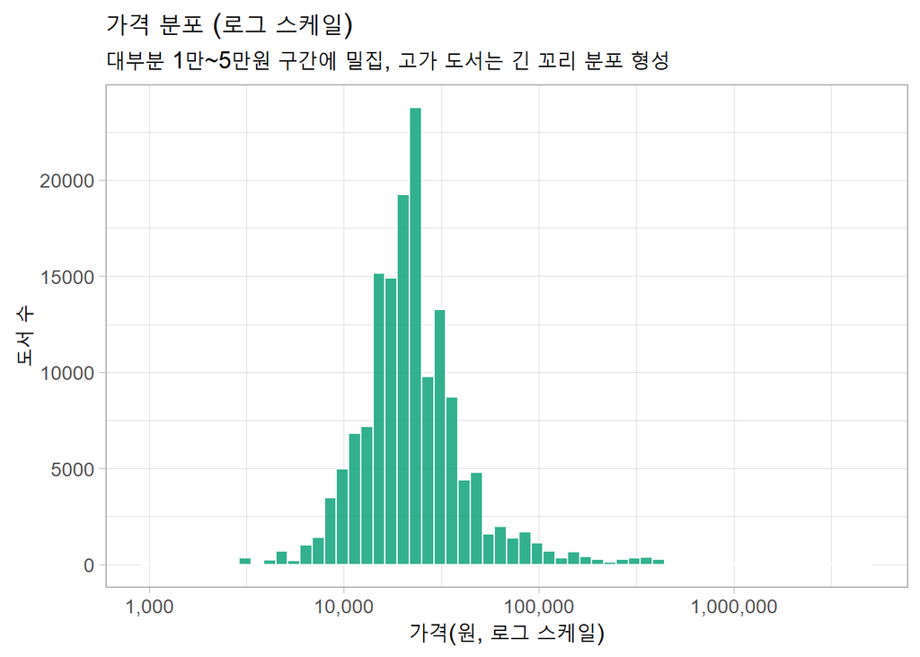

```r
ggplot(df_clean, aes(가격)) +
  geom_histogram(bins = 60, fill = "#009E73", color = "white", alpha = 0.8) +
  scale_x_log10(labels = comma_format()) +
  labs(
    title = "가격 분포 (로그 스케일)",
    subtitle = "대부분 1만~5만원 구간에 밀집, 고가 도서는 긴 꼬리 분포 형성",
    x = "가격(원, 로그 스케일)",
    y = "도서 수"
  ) +
  theme_light(base_size = 13)
```

- 일반 도서는 1만~5만원에 가장 많이 분포
- 10만원 이상 고가 도서는 극히 적지만 **두꺼운 꼬리 형태(heavy tail)**

## **5. 고가 도서 분포(10만원 이상)**

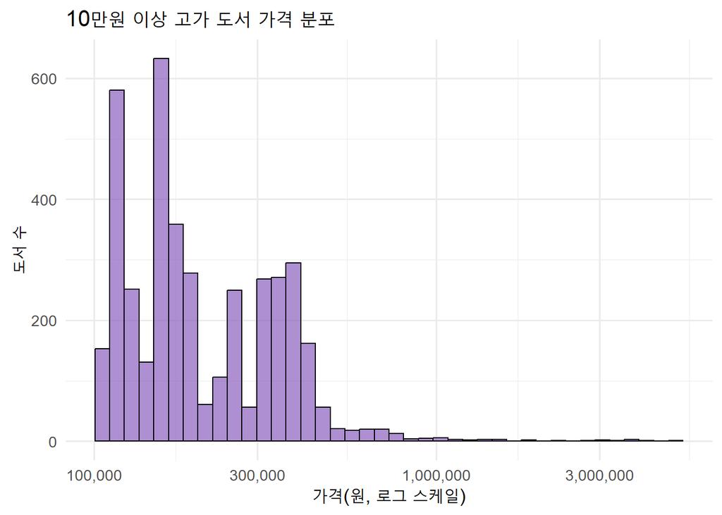

```r
df_clean %>%
  filter(가격 > 100000) %>%
  ggplot(aes(가격)) +
  geom_histogram(bins = 40, fill = "#8B5FBF", color = "black", alpha = 0.7) +
  scale_x_log10(labels = comma_format()) +
  labs(
    title = "10만원 이상 고가 도서 가격 분포",
    x = "가격(원, 로그 스케일)",
    y = "도서 수"
  ) +
  theme_minimal(base_size = 13)
```

```r
high_price_count <- df_clean %>%
  filter(가격 > 100000) %>%
  summarise(n = n())

high_price_count
```

```
## # A tibble: 1 × 1
##       n
##   <int>
## 1  4040
```

- 10만원 이상 고가 도서는 4,040권으로 전체의 약 2.6%

```r
high_price_count2 <- df_clean %>%
  filter(가격 > 1000000) %>%
  summarise(n = n())

high_price_count2
```

```
## # A tibble: 1 × 1
##       n
##   <int>
## 1    25
```

- 100만원이 넘어가는 초고가 도서 존재

## **6. 발행일 분포**

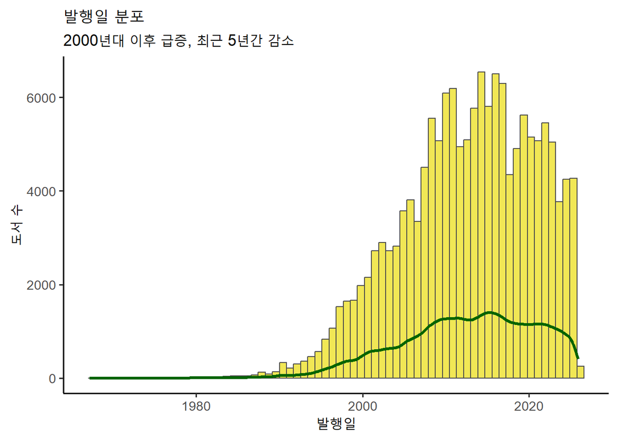

```r
ggplot(df_clean %>% filter(!is.na(발행일)), aes(발행일)) +
  geom_histogram(bins = 70, fill = "#F0E442", color = "gray30", alpha = 0.9) +
  geom_density(aes(y = ..count.. * 70), color = "darkgreen", size = 1.1, alpha = 0.7) +
  labs(
    title = "발행일 분포",
    subtitle = "2000년대 이후 급증, 최근 5년간 감소",
    x = "발행일",
    y = "도서 수"
  ) +
  theme_classic(base_size = 13)
```

- 1980년대 후반까지는 출판량이 적음
- 2000년대 이후 출판량 폭발적으로 증가 2020이후 구간에서 다소 하락

# **Resonance**

`-` 그러면 왜 대학교재는 점점 줄어들까?

[output not shown]

# **Insight**

`-` Data와 Resonance 분석을 종합하면, 교재 감소는 단순한 시장 축소가 아니라  
**한국 대학 교육 생태계가 디지털·AI 중심 구조로 재편되는 과정**이라는 사실이 드러남

이 변화는 **교육부**의 제6차(2019~2023), 2021·2022 시행계획, 제7차(2024~2028) 교육정보화 계획에서  
강조된 방향성과 일치함

참고자료 (PDF 원문)

- 📄 제6차 교육정보화 기본계획(2019–2023)
- 📄 2021 교육정보화 시행계획
- 📄 2022 교육정보화 시행계획
- 📄 제7차 교육정보화 기본계획(2024–2028)

아래 3개의 Insight는 이러한 구조적 전환을 설명함

## **Insight 1. 교재 감소 → 대학 학습 단위의 디지털 재조합의 진행**

✔ 즉, 교재는 더 이상 책이라는 고정 단위가 아니라  
→ **슬라이드·모듈형 콘텐츠·요약본·문제은행**으로 분해되고  
→ 교수·학생이 AI 도구와 함께 조합하는 방식으로 변하고 있음

> **대학 교재 감소는 학습 단위의 해체·재조합이라는 구조적 변화의 결과로 볼 수 있음**

## **Insight 2. 대학 출판·교육자료 시장 → AI 활용 가능한 학습 리소스 공급 체계로 이동**

✔ 앞으로 출판사의 경쟁력은  
→ **AI가 이해하고 가공할 수 있는 구조화된 학습 리소스를 제공하는가**로 결정됨

> **출판 = 콘텐츠 × 데이터 × AI 활용성**이라는 새로운 패러다임이 형성되고 있음

## **Insight 3. 대학생의 학습 방식 → AI 리터러시 기반으로 재편**

- **Data:** 종이교재 감소 + PDF 강의자료 중심 + 고가 도서 접근성 문제
- **Resonance:** 요약·번역·문제풀이 등 주요 기능을 AI가 대체
- **정책 근거:**
  - **제6차·7차 계획 공통:**
    - 디지털 소양을 미래 기초역량으로 규정
    - AI 기반 학습지원 서비스 확대
    - AI 활용 평가체계(CBT·지능형 피드백) 도입
  - 대학은 교육부 지원 아래 AI 도입, AI 기반 학습플랫폼 구축을 확대 중

✔ 따라서 학생 역량의 중심축은  
→ “교재를 정독하는 능력”에서  
→ **AI를 활용·판단·조합하는 능력(AI Literacy)** 으로 이동하고 있음

이는 대학 교육의 경쟁력이  
**콘텐츠 이해력 → AI 활용력**으로 넘어가고 있음을 의미함

> **교재 감소는 학습 방식이 AI 중심 패러다임으로 전환되고 있음**

## **Insight — 한 줄 요약**

> 대학교재 감소는 위기가 아니라,  
> 대학 교육이 AI 기반 지능형 학습 체계로 이동하는 구조적 전환의 신호이며  
> 대학·출판사·학생의 역할이 모두 재정의되는 변곡점이다

# **Problem**

`-` Insight 분석을 종합하면, 교재 감소는 단순한 출판 감소가 아니라  
**대학생의 학습 방식이 디지털·AI 중심 구조로 이동하고 있다는 신호임**

그러나 학습 방식의 변화 속도와  
**산업계가 요구하는 AI 기반 실무 역량의 변화 속도는 일치하지 않음**

이로 인해 자연스럽게 다음과 같은 문제가 나타나고 있음:

> “기업이 요구하는 역량”과  
> “대학생이 실제로 준비하는 역량” 사이의 격차가 커지고 있음

따라서 문제의 핵심 질문은 단순히

“교재가 줄었는가?”가 아니라,  
“기업이 요구하는 AI 기반 역량을 대학생이 충분히 준비하고 있는가?” 임

## **Problem 1. 기업은 지식 ’암기형 인재’가 아니라 ’AI 기반 문제 해결형 인재’를 요구**

### ✔ 국내 주요 기업들의 ‘AI 활용 역량’ 요구 근거 (정리 표)

| 기업 | 공식 문구 / 발표 내용 | 출처 |
| --- | --- | --- |
| **카카오 (2025 신입 공채)** | *“AI 기술 활용에 익숙하고 적극적인 ‘AI 네이티브’ 인재 우대”* | https://www.kakaocorp.com/page/detail/11688?lang=KOR |
| **SK텔레콤 (AI R&D 채용 2025)** | LLM·멀티모달 모델 등 **AI 기반 서비스·연구 경험**을 주요 요구 역량으로 제시 | https://linkareer.com/activity/273045 |
| **삼성SDS (2024~2025 채용 흐름)** | 클라우드 자동화, 생성형 AI 서비스 기획·개발 경험을 **우대사항**으로 명시한 공고 증가 | https://kowork.kr/en/post/3486 |
| **LG CNS (공식 직무 소개)** | *“LG CNS는 AX(AI Transformation) 기업으로 AI 기술을 고객 산업 전반에 적용한다”* → **AI 컨설팅·AI Engineering 등 Full-stack AI 활용 역량 요구** | https://www.lgcns.com/kr/careers/job/ai.html |

**➜ 의미**

- 기업은 이제 **전공 지식량보다 AI를 활용한 문제 해결 역량을 더 높은 가치로 평가**하고 있음
- 그러나 대학 수업은 여전히 **교재 기반·암기 중심 평가**에 머무르는 경우가 많아, 기업이 요구하는 역량과 대학생이 준비하는 역량의 간극이 커지고 있음

## **Problem 2. 산업계는 AI 협업 역량을 요구하지만, 대학 교육은 이를 충분히 제공하지 못함**

### ✔ 글로벌 보고서 근거

- **Deloitte AI Industry Report (2024)**  
  → “전 산업의 핵심 경쟁력은 **AI-assisted work**로 이동 중”이라고 분석함
- **McKinsey *Future of Work* (2023)**  
  → “**AI와 협업하며 일할 수 있는 역량(AI-augmented skill)** 이  
  신규 채용에서 가장 중요한 역량 중 하나”라고 제시함

### ✔ 실제 직무 변화 예시

| 산업 | 과거 업무 방식 | 현재/미래 요구 역량 |
| --- | --- | --- |
| 마케팅 | 보고서 작성, 자료조사 수작업 | AI 기반 시장 분석, 자동 리포트 생성 |
| 데이터·개발 | 수작업 코딩·전처리 | Copilot 기반 개발, AI 코드 리뷰, 프롬프트 설계 |
| 경영·기획 | 엑셀·PPT 기반 정적 분석 | AI 활용 전략 시뮬레이션, 시나리오 플래닝 |
| 교육·출판 | 종이 교재 제작 중심 | AI 코스웨어, 디지털 학습 리소스·플랫폼 설계 |

**➜ 의미**

- 겉으로는 PDF·슬라이드 중심 디지털 강의가 확대되었지만,실제로 산업에서 요구하는 역량은 **AI와 협업하는 실무 능력**임
- 그러나 이러한 역량은 현행 대학 교육만으로는 충분히 준비하기 어려운 구조임

## **Problem 3. AI 확산 - 학생 간 역량 격차 증가**

### ✔ 실제로 나타나는 현상

- **AI 활용이 능숙한 학생**: 분석·정리·코딩·문서 작성까지 자동화 → 성과 급상승
- **AI 활용이 미숙한 학생**: 모든 작업을 수작업으로 수행 → 속도·결과 모두 뒤처짐

과거에는 모두가 동일한 교재로 비슷한 출발선을 가졌지만,  
이제는 **AI 활용 능력 자체가 학습 성과·취업 경쟁력을 결정하는 핵심 변수**가 됨

즉,

> AI를 잘 쓰는 학생과 그렇지 못한 학생의 격차는  
> 교재 시대보다 훨씬 더 빠르고 크게 벌어지고 있음

## **Problem 4. 앞으로 대학 경쟁력을 결정하는 것은 ‘전공 지식’이 아니라 ‘AI 기반 실무 역량’**

### ✔ 앞으로 대학생이 반드시 갖춰야 할 5대 핵심 역량

1. **AI 활용 능력 (AI Literacy)**
   - ChatGPT, Copilot 등 **생성형 AI 도구를 활용한 분석·요약·문제 해결**
   - AI 결과물의 타당성을 검증하는 **비판적 사고력**
   - 업무·학습 맥락에 맞는 **프롬프트 설계 능력**
2. **디지털 데이터 해석 능력**
   - PDF, 리포트, 온라인 자료 등 디지털 텍스트·표·그래프를  
     **구조적으로 읽고, 필요한 정보를 추출·조합하는 능력**
3. **자동화·생산성 도구 활용 능력**
   - 반복 작업을 줄이고,  
     **AI + 스크립트 + 툴(예: 노션, 파이썬, R, Zapier 등)** 을 조합해  
     워크플로우를 설계·자동화하는 능력
4. **프로젝트 기반 문제 해결 능력**
   - 이론 암기가 아니라,  
     **“문제를 정의 → 데이터·AI를 활용해 해결안 설계 → 결과물로 보여주는 능력”**
   - 기업은 성적보다 **포트폴리오·프로젝트 경험**을 더 중요하게 보는 추세임
5. **디지털 커뮤니케이션 능력**
   - AI를 활용한 문서·리포트 작성,
   - 협업툴(Jira, Notion, GitHub 등)을 통한 팀 단위 소통과 기록 관리 능력

## **Problem — 최종 정리**

> 교재 감소는 단순한 출판 시장의 변화가 아니라,  
> 대학생에게 요구되는 역량의 기준이 바뀌고 있다는 신호임

> 기업은 이미 **AI와 함께 일할 수 있는 실무형 인재**를 요구하고 있지만,  
> 많은 대학생은 여전히 **교재·시험 중심 학습 구조**에 머물러 있음

> 따라서 지금 필요한 것은 교재의 대체가 아니라,  
> AI 시대에 생존 가능한 역량을 학생들이 갖출 수 있도록  
> 학습·교육의 방향을 재설정하는 것임